# homework-week-6

Ingrid Lundeen

October 17, 2016

# Using a new .Rmd file and pushing both the markdown and knitted .html file to a new repository named “homework-week-6” on your GitHub page, answer the following questions:

# [1] Write a simple R function, Z.prop.test(), that can perform one- or two-sample Z-tests for proportion data, using the following guidelines.

### Your function should take the following arguments: p1 and n1 (no default) to pose as the estimated proportion and sample size (i.e., based on your sample data); p2 and n2 (both defaulting to NULL) that contain a second sample’s proportion and sample size data in the event of a two-sample test; p0 (no default) as the expected value for the population proportion; and alternative (default “two.sided”) and conf.level (default 0.95), to be used in the same way as in the function t.test().

### When conducting a two-sample test, it should be p1 that is tested as being smaller or larger than p2 when alternative=“less” or alternative=“greater”, the same as in the use of x and y in the function t.test().

### The function should perform a one-sample Z-test using p1, n1, and p0 if either p2 or n2 (or both) is NULL.

### The function should return a list containing the members Z (the test statistic), P (the appropriate p-value), and CI (the two-sided CI with respect to confidence level).

```r
Z.prop.test <- function(P1,N1,P2=NULL,N2=NULL,P0,alternative="two.sided",conf.level=0.95){ #specifying that arguments the function is going to use and specifying that by default, P2 and N2 should be null
  if(is.null(P2)||is.null(N2)){ #saying that if P2 OR N2 is NULL -  the function will do the following
    cat("One-sample Z-test.\n")
    if(P1*N1<=5||N1*(1-P1)<=5){ #checking to make sure that the sample size is large enough to assume normality in the data
      warning("WARNING - Probably not a normal distribution") #what the function will spit out if either of those equations tested is less than or equal to five
    }
    Z <- (P1-P0)/sqrt(P0*(1-P0)/N1) #producing a z-statistic for a one sample z-test
    CI <- (P1)+c(-1,1)*qnorm(conf.level+(1-conf.level)/2)*sqrt(P0*(1-P0)/N1) #producing a confidence interval for a one sample z-test.
  } else { #bringing it back to that initial if...else statement - if P2 and N2 are NOT null.
    cat("Two-sample Z-test.\n")
    if(P1*N1<=5||N1*(1-P1)<=5||P2*N2<=5||N2*(1-N2)<=5){ #testing for the appropriate sample size to assume normality
      warning("WARNING - Probably not a normal distribution") #what R will spit out if the sample isn't large enough to assume normality - although it will still run.
    }
#The function should contain a check for the rules of thumb we have talked about ($n * p > 5$ and $n * (1-p) >5$) to ensure the validity of assuming the normal distribution in both the one- and two-sample settings. If this is violated, the function should still complete but it should also print an appropriate warning message.
    P.STAR <- (P1*N1+P2*N2)/(N1+N2) #calculating the pooled proportion so we can calculate a 2-sample z-test
    Z <- (P1-P2-P0)/sqrt(P.STAR*(1-P.STAR)*(1/N1+1/N2)) #calculating the z-statistic for a 2-sample z-test
    CI <- sort((P1-P2)+c(-1,1)*qnorm(conf.level+(1-conf.level)/2)*sqrt(P.STAR*(1-P.STAR)*(1/N1+1/N2))) #
  }

  if(alternative=="greater"){ #set the argument to default to 2 sided so if we set it as greater instead than we want to calculate it this way -
    P <- pnorm(Z, lower.tail=FALSE)
  } else if(alternative =="less"){ #if we set it to less  - calculate P this way
    P <- pnorm(Z, lower.tail=TRUE)
    } else if(alternative=="two.sided"){ #if it defaults on twosided we calculate it this way
     if (Z > 0) {P<-2*pnorm(z,lower.tail=FALSE)}
            if (Z < 0) {P<-2*pnorm(z,lower.tail=TRUE)}
    }
  return(list(Z=Z,P=P,CI=CI)) #asking it to return a list with the z-statistic, the p-value, and the associated confidence intervals
}
```

# [2] The dataset from Kamilar and Cooper has in it a large number of variables related to life history and body size. For this exercise, the end aim is to fit a simple linear regression model to predict longevity (“MaxLongevity_m”) measured in months from species’ brain size (“Brain_Size_Species_Mean”) measured in grams. Do the following for both longevity~brain size and log(longevity)~log(brain size).

```r
library(curl)
```

```r
library(ggplot2)
f <- curl("https://raw.githubusercontent.com/difiore/ADA2016/master/KamilarAndCooperData.csv")
d <- read.csv(f, header = TRUE, sep = ",", stringsAsFactors = FALSE)
head(d)
```

```
##               Scientific_Name          Family          Genus      Species
## 1 Allenopithecus_nigroviridis Cercopithecidae Allenopithecus nigroviridis
## 2         Allocebus_trichotis Cercopithecidae      Allocebus    trichotis
## 3           Alouatta_belzebul        Atelidae       Alouatta     belzebul
## 4             Alouatta_caraya        Atelidae       Alouatta       caraya
## 5            Alouatta_guariba        Atelidae       Alouatta      guariba
## 6           Alouatta_palliata        Atelidae       Alouatta     palliata
##   Brain_Size_Species_Mean Brain_Size_Female_Mean   Brain_size_Ref
## 1                   58.02                  53.70 Isler et al 2008
## 2                      NA                     NA
## 3                   52.84                  51.19 Isler et al 2008
## 4                   52.63                  47.80 Isler et al 2008
## 5                   51.70                  49.08 Isler et al 2008
## 6                   49.88                  48.04 Isler et al 2008
##   Body_mass_male_mean Body_mass_female_mean Mass_Dimorphism
```

[output cut: 69 more lines]

```r
m <- lm(MaxLongevity_m ~ Brain_Size_Species_Mean , data = d)
m
```

```
##
## Call:
## lm(formula = MaxLongevity_m ~ Brain_Size_Species_Mean, data = d)
##
## Coefficients:
##             (Intercept)  Brain_Size_Species_Mean
##                 248.952                    1.218
```

```r
summary(m)
```

```
##
## Call:
## lm(formula = MaxLongevity_m ~ Brain_Size_Species_Mean, data = d)
##
## Residuals:
##     Min      1Q  Median      3Q     Max
## -198.27  -61.92  -17.78   56.16  331.36
##
## Coefficients:
##                         Estimate Std. Error t value Pr(>|t|)
## (Intercept)             248.9523    11.1111   22.41   <2e-16 ***
## Brain_Size_Species_Mean   1.2180     0.1101   11.06   <2e-16 ***
## ---
## Signif. codes:  0 '***' 0.001 '**' 0.01 '*' 0.05 '.' 0.1 ' ' 1
##
## Residual standard error: 90.91 on 126 degrees of freedom
##   (85 observations deleted due to missingness)
## Multiple R-squared:  0.4928, Adjusted R-squared:  0.4887
## F-statistic: 122.4 on 1 and 126 DF,  p-value: < 2.2e-16
```

```r
logm<-lm(log(MaxLongevity_m)~log(Brain_Size_Species_Mean), data=d)
logm
```

```
##
## Call:
## lm(formula = log(MaxLongevity_m) ~ log(Brain_Size_Species_Mean),
##     data = d)
##
## Coefficients:
##                  (Intercept)  log(Brain_Size_Species_Mean)
##                       4.8790                        0.2341
```

```r
summary(logm)
```

```
##
## Call:
## lm(formula = log(MaxLongevity_m) ~ log(Brain_Size_Species_Mean),
##     data = d)
##
## Residuals:
##     Min      1Q  Median      3Q     Max
## -0.6955 -0.1750 -0.0097  0.1788  0.6084
##
## Coefficients:
##                              Estimate Std. Error t value Pr(>|t|)
## (Intercept)                   4.87895    0.06907   70.63   <2e-16 ***
## log(Brain_Size_Species_Mean)  0.23415    0.01781   13.15   <2e-16 ***
## ---
## Signif. codes:  0 '***' 0.001 '**' 0.01 '*' 0.05 '.' 0.1 ' ' 1
##
## Residual standard error: 0.2485 on 126 degrees of freedom
##   (85 observations deleted due to missingness)
## Multiple R-squared:  0.5784, Adjusted R-squared:  0.5751
## F-statistic: 172.9 on 1 and 126 DF,  p-value: < 2.2e-16
```

### Fit the regression model and, using {ggplot2}, produce a scatterplot with the fitted line superimposed upon the data. Append the the fitted model equation to your plot (HINT: use the function geom_text()).

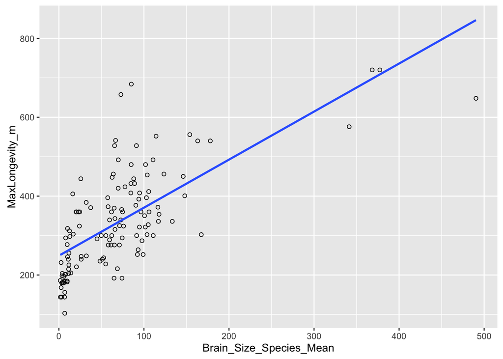

```r
plotM<-ggplot(d, aes(x=Brain_Size_Species_Mean, y=MaxLongevity_m)) +
    geom_point(shape=1) +    # Use hollow circles
    geom_smooth(method=lm, se=FALSE)   # Add linear regression line w/o confidence lines
plotM
```

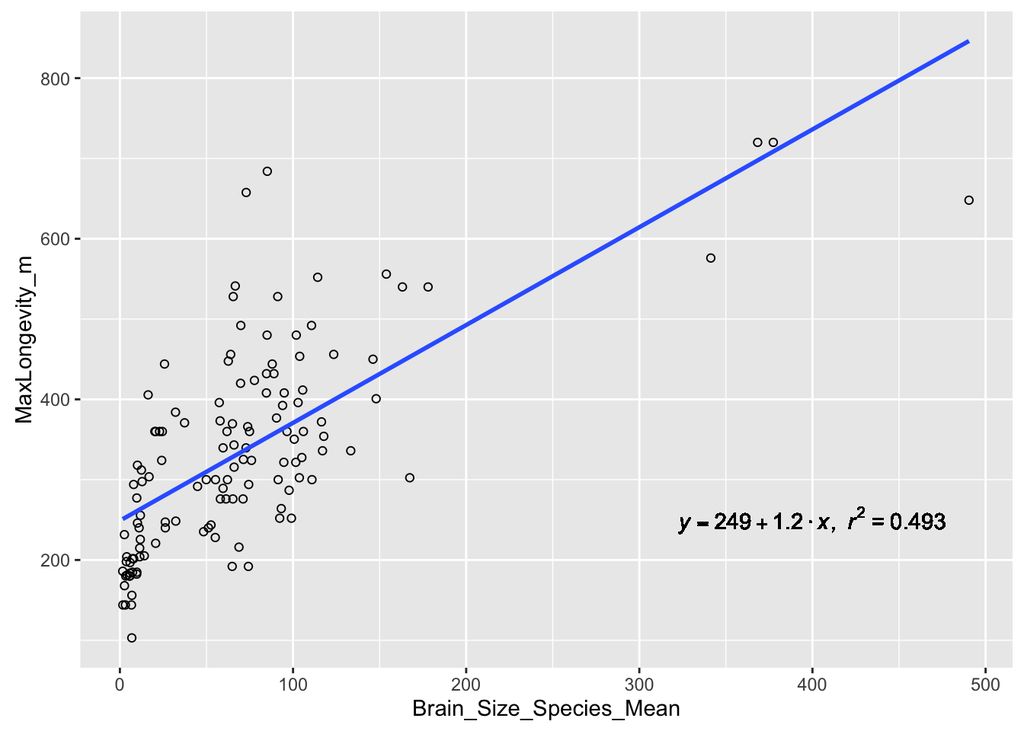

```r
#use a function that turns linear model information into equation
lm_eqn = function(m) {

  l <- list(a = format(coef(m)[1], digits = 2),
      b = format(abs(coef(m)[2]), digits = 2),
      r2 = format(summary(m)$r.squared, digits = 3));

  if (coef(m)[2] >= 0)  {
    eq <- substitute(italic(y) == a + b %.% italic(x)*","~~italic(r)^2~"="~r2,l)
  } else {
    eq <- substitute(italic(y) == a - b %.% italic(x)*","~~italic(r)^2~"="~r2,l)
  }

  as.character(as.expression(eq));
}
plotM1 <- plotM + geom_text(aes(x = 400, y = 250, label = lm_eqn(lm(d$MaxLongevity_m ~ d$Brain_Size_Species_Mean))), parse = TRUE)
plotM1
```

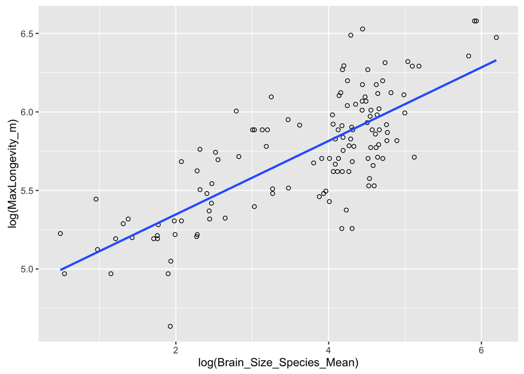

```r
logplotM<-ggplot(d, aes(x=log(Brain_Size_Species_Mean), y=log(MaxLongevity_m))) +
    geom_point(shape=1) +    # Use hollow circles
    geom_smooth(method=lm, se=FALSE)   # Add linear regression line w/o confidence lines
logplotM
```

[figure not shown]

```r
logplotM1<-logplotM+geom_text(aes(x = 5, y = 5, label = lm_eqn(lm(d$MaxLongevity_m ~ d$Brain_Size_Species_Mean))), parse = TRUE)
logplotM1
```

```r
summary(m)
```

```
##
## Call:
## lm(formula = MaxLongevity_m ~ Brain_Size_Species_Mean, data = d)
##
## Residuals:
##     Min      1Q  Median      3Q     Max
## -198.27  -61.92  -17.78   56.16  331.36
##
## Coefficients:
##                         Estimate Std. Error t value Pr(>|t|)
## (Intercept)             248.9523    11.1111   22.41   <2e-16 ***
## Brain_Size_Species_Mean   1.2180     0.1101   11.06   <2e-16 ***
## ---
## Signif. codes:  0 '***' 0.001 '**' 0.01 '*' 0.05 '.' 0.1 ' ' 1
##
## Residual standard error: 90.91 on 126 degrees of freedom
##   (85 observations deleted due to missingness)
## Multiple R-squared:  0.4928, Adjusted R-squared:  0.4887
## F-statistic: 122.4 on 1 and 126 DF,  p-value: < 2.2e-16
```

```r
newdata1 = data.frame(Brain_Size_Species_Mean=248.95)
mint<-predict(m, newdata1, interval="confidence", level=0.90)
```

## The point estimate of the slope for the non-log-transformed regression shows that on average, with each 1 unit increase in brain size, the max longevity increases by 1.22. Additionally, since the p-value is well below 0.05, we could reject the null hypothesis that beta_1=0.

```r
summary(logm)
```

```
##
## Call:
## lm(formula = log(MaxLongevity_m) ~ log(Brain_Size_Species_Mean),
##     data = d)
##
## Residuals:
##     Min      1Q  Median      3Q     Max
## -0.6955 -0.1750 -0.0097  0.1788  0.6084
##
## Coefficients:
##                              Estimate Std. Error t value Pr(>|t|)
## (Intercept)                   4.87895    0.06907   70.63   <2e-16 ***
## log(Brain_Size_Species_Mean)  0.23415    0.01781   13.15   <2e-16 ***
## ---
## Signif. codes:  0 '***' 0.001 '**' 0.01 '*' 0.05 '.' 0.1 ' ' 1
##
## Residual standard error: 0.2485 on 126 degrees of freedom
##   (85 observations deleted due to missingness)
## Multiple R-squared:  0.5784, Adjusted R-squared:  0.5751
## F-statistic: 172.9 on 1 and 126 DF,  p-value: < 2.2e-16
```

```r
newdata2 = data.frame(Brain_Size_Species_Mean=4.87)
logmint<-predict(logm, newdata2,interval="confidence", level=0.90)
```

### Using your model, add lines for the 90 percent confidence and prediction interval bands on the plot and add a legend to differentiate between the lines.

```r
#non-log-transformed data
m <- lm(data = d, MaxLongevity_m ~ Brain_Size_Species_Mean)
h_hat <- predict(m, newdata = data.frame(Brain_Size_Species_Mean = d$Brain_Size_Species_Mean))
df <- data.frame(cbind(d$Brain_Size_Species_Mean, d$MaxLongevity_m, h_hat))
names(df) <- c("x", "y", "yhat")
head(df)
```

```
##       x     y     yhat
## 1 58.02 276.0 319.6201
## 2    NA    NA       NA
## 3 52.84    NA 313.3109
## 4 52.63 243.6 313.0551
## 5 51.70    NA 311.9224
## 6 49.88 300.0 309.7056
```

```r
ci <- predict(m, newdata = data.frame(Brain_Size_Species_Mean = d$Brain_Size_Species_Mean), interval = "confidence", level = 0.90)  # for a vector of values
head(ci)
```

```
##        fit      lwr      upr
## 1 319.6201 306.1354 333.1047
## 2       NA       NA       NA
## 3 313.3109 299.6449 326.9768
## 4 313.0551 299.3805 326.7297
## 5 311.9224 298.2081 325.6366
## 6 309.7056 295.9081 323.5032
```

```r
df <- cbind(df, ci)
names(df) <- c("x", "y", "yhat", "CIfit", "CIlwr", "CIupr")
head(df)
```

```
##       x     y     yhat    CIfit    CIlwr    CIupr
## 1 58.02 276.0 319.6201 319.6201 306.1354 333.1047
## 2    NA    NA       NA       NA       NA       NA
## 3 52.84    NA 313.3109 313.3109 299.6449 326.9768
## 4 52.63 243.6 313.0551 313.0551 299.3805 326.7297
## 5 51.70    NA 311.9224 311.9224 298.2081 325.6366
## 6 49.88 300.0 309.7056 309.7056 295.9081 323.5032
```

```r
pi <- predict(m, newdata = data.frame(Brain_Size_Species_Mean = d$Brain_Size_Species_Mean), interval = "prediction",
     level = 0.90)  # for a vector of values
head(pi)
```

```
##        fit      lwr      upr
## 1 319.6201 168.3750 470.8651
## 2       NA       NA       NA
## 3 313.3109 162.0496 464.5722
## 4 313.0551 161.7930 464.3172
## 5 311.9224 160.6567 463.1880
## 6 309.7056 158.4324 460.9789
```

```r
df <- cbind(df, pi)
names(df) <- c("x", "y", "yhat", "CIfit", "CIlwr", "CIupr", "PIfit", "PIlwr",
     "PIupr")
head(df)
```

```
##       x     y     yhat    CIfit    CIlwr    CIupr    PIfit    PIlwr
## 1 58.02 276.0 319.6201 319.6201 306.1354 333.1047 319.6201 168.3750
## 2    NA    NA       NA       NA       NA       NA       NA       NA
## 3 52.84    NA 313.3109 313.3109 299.6449 326.9768 313.3109 162.0496
## 4 52.63 243.6 313.0551 313.0551 299.3805 326.7297 313.0551 161.7930
## 5 51.70    NA 311.9224 311.9224 298.2081 325.6366 311.9224 160.6567
## 6 49.88 300.0 309.7056 309.7056 295.9081 323.5032 309.7056 158.4324
##      PIupr
## 1 470.8651
## 2       NA
## 3 464.5722
## 4 464.3172
## 5 463.1880
## 6 460.9789
```

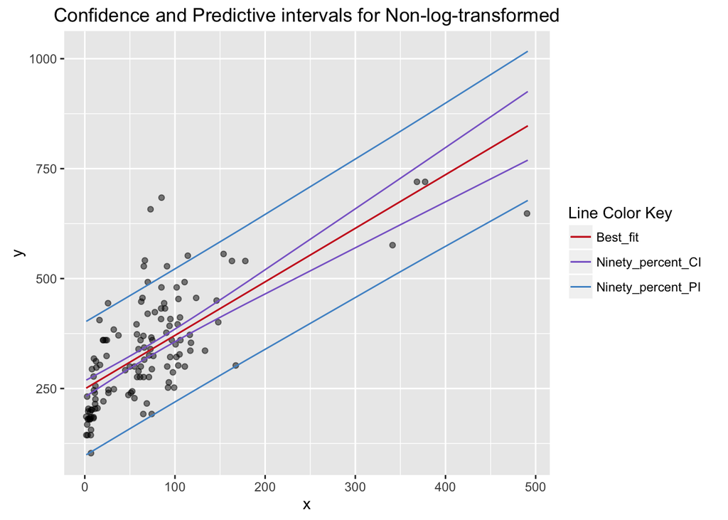

```r
plotm <- ggplot(data = df, aes(x = x, y = y)) +
  geom_point(alpha = 1/2) +
  ggtitle("Confidence and Predictive intervals for Non-log-transformed") +
  geom_line(aes(x = x, y = CIfit, colour = "Best_fit")) +
  geom_line(aes(x = x, y = CIlwr, colour = "Ninety_percent_CI")) +
  geom_line(aes(x = x, y = CIupr, colour = "Ninety_percent_CI")) +
  geom_line(aes(x = x, y = PIfit, colour = "Best_fit")) +
  geom_line(aes(x = x, y = PIlwr, colour = "Ninety_percent_PI")) +
  geom_line(aes(x = x, y = PIupr, colour = "Ninety_percent_PI")) + scale_colour_manual(name="Line Color Key",values=c(Best_fit="firebrick3",Ninety_percent_CI="mediumpurple3", Ninety_percent_PI="steelblue3"))
plotm
```